# LifeGenMon Fagus SNP analysis - Fst outliers

Nikos Tourvas

2019-07-01

# F<sub>ST</sub> Outliers - Signals of Selection

## Data filtering thresholds

```
[1] "SNP loci: 10 % missing data across populations"
[1] "Individuals: 10 % missing data"
[1] "SNP loci with minor allele frequency < 0.00775193798449612"
```

MAF corresponds to 5 samples (i.e. an allele has to be present in 5 or more individuals, or else it is discarded)

## Data set details after data filtering:

```
[1] "645 individuals and 139 loci"
```

## PCAdapt (Luu, Bazin, and Blum 2017)

Each of the three countries was considered a cohort.

This method is based on principal component analysis (PCA). The user should specify the number K of principal components (PC) to work with: first perform with a large number of principal components (e.g. higher than the number of populations), then use the ‘scree plot’ to chose the value of K. It displays the percentage of variance that is explained by each PC. The recommended value of K corresponds to the largest value of K before the plateau of ‘scree plot’ is reached. Then for a given SNP, a statistical test to define the SNP as outlier or not is based on the “loadings” that are defined as the correlation between the SNP and the PCs. The statistic test for detecting outlier SNPs is the Mahalanobis distance (between the K correlations of the SNP and each axis and mean correlations) and, which scaled by a constant, should have a chi-square distribution with K degrees of freedom under the assumption that there are no outlier. By default P-values of SNPs with a minor allele frequency smaller than 0.05 are not computed. A Manhattan plot displays log10 of the p-values. It is also possible to check the distribution of the p-values using a Q-Q plot. The authors suggest to use false discovery rate (q-value) to provide a list of outliers.

By contrast to population‐based approaches, the method handles admixed individuals and does not require grouping individuals into populations.

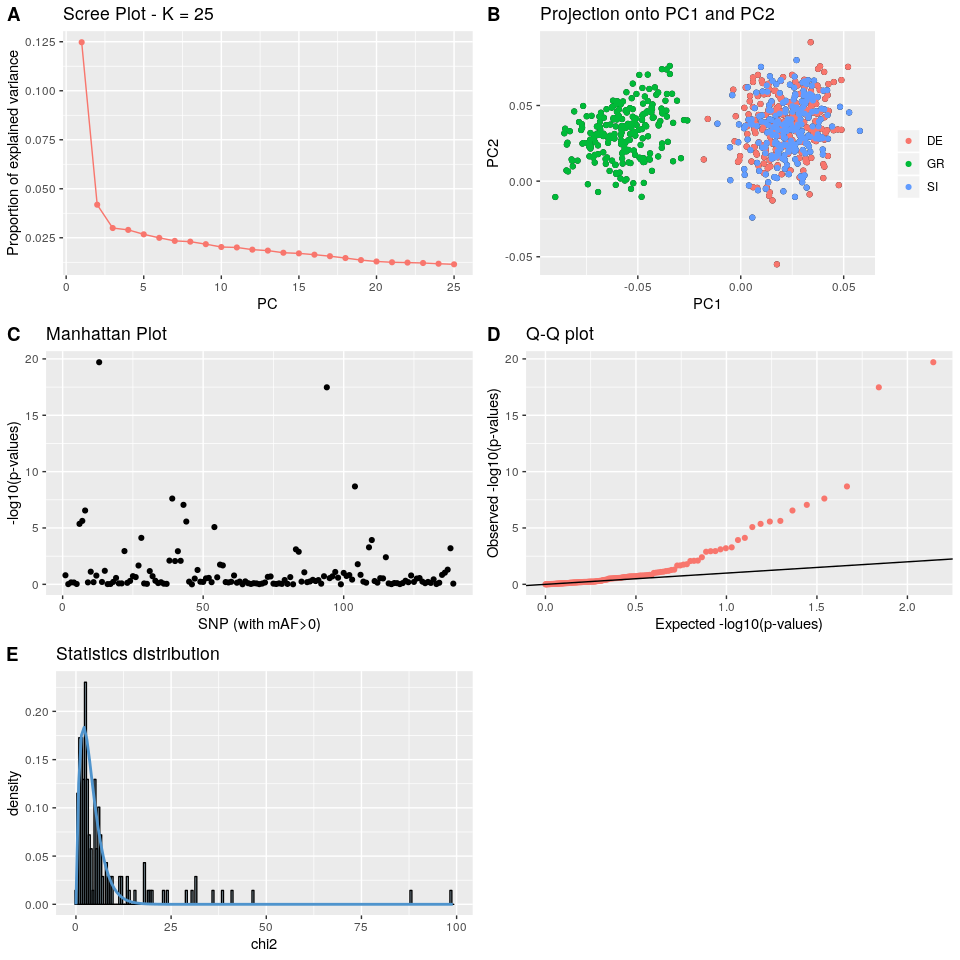

```
 [1] "14_388"    "14_429"    "17_880"    "19_520"    "27_438"    "50_441"    "66_698"    "68_277"
 [9] "73_93"     "73_166"    "130_85"    "154_1_715" "154_1_845" "155_2_556" "23_1_475"  "51_2_937"
[17] "52_1_152"  "61_2_596"  "80_748"
```

## Outflank (Whitlock and Lotterhos 2015)

Each of the three countries was considered a cohort.

It implements the method developed by Whitlock and Lotterhos (2015) to use likelihood on a trimmed distribution of FST values to infer the distribution of FST for neutral markers. This distribution is then used to assign q-values to each locus to detect outliers that may be due to spatially heterogeneous selection.

```
Calculating FSTs, may take a few minutes...
```

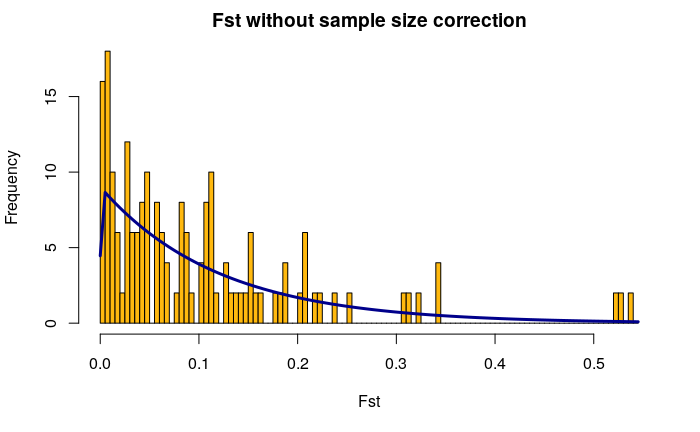

No outlier loci were detected.

## Bayescan (Foll and Gaggiotti 2008)

Each of the three countries was considered a cohort.

Default settings were used.

```
$outliers
integer(0)

$nb_outliers
[1] 0
```

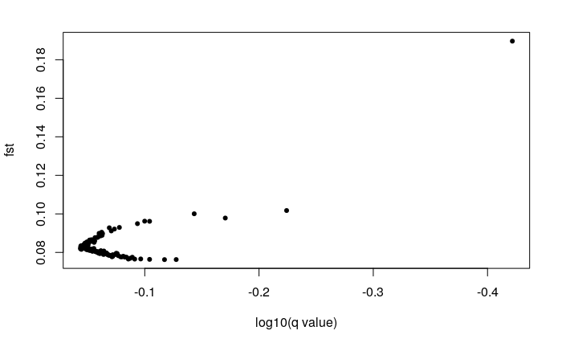

```
character(0)
```

## Arlequin - Fdist (Beaumont Mark A. and Nichols Richard A. 1996)

Each of the three countries was considered a cohort. The analysis is based on the island model of Beaumont and Nichols (1996).

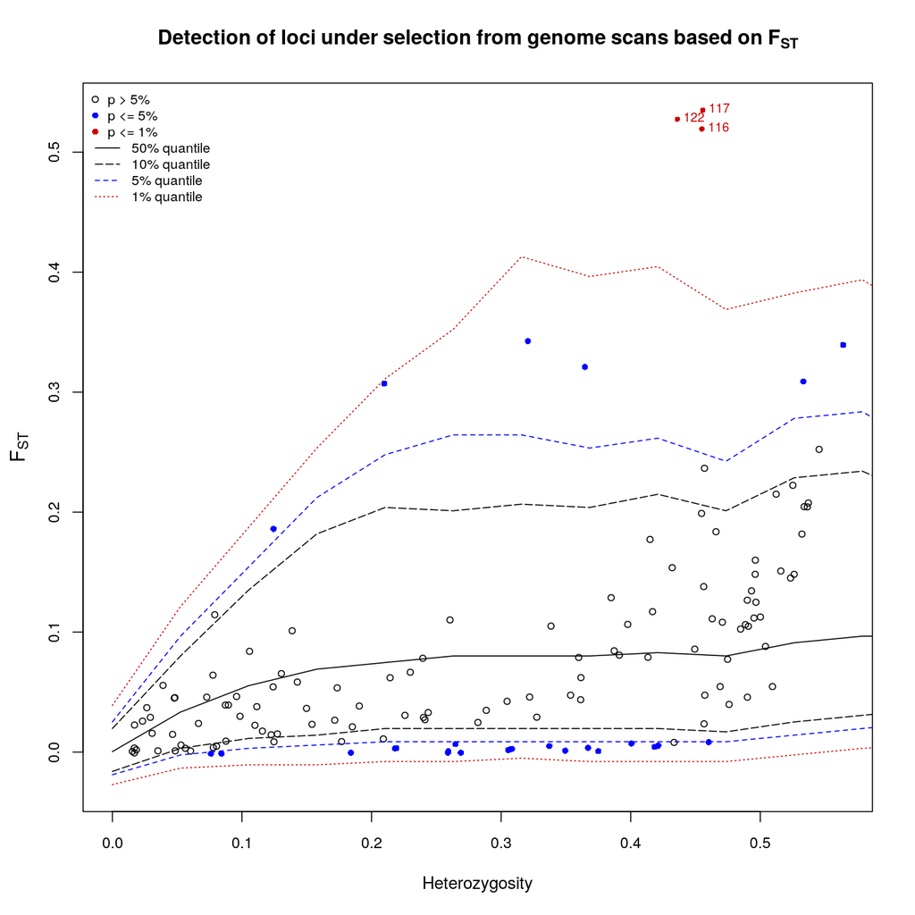

```
[1] "62_1_148" "98_1_305" "62_1_538"
```

### Multiple test correction

```
character(0)
```

After correction for multiple testing (FDR=0.05), 0 outlier SNP loci were detected.

## Arlequin - HFdist Hierarchical model (Excoffier, Hofer, and Foll 2009)

Each of the three countries was considered a cohort. Due to the fact that the Slovenian and German cohorts share more recent ancestry, the HFdist hierarchical model was employed.

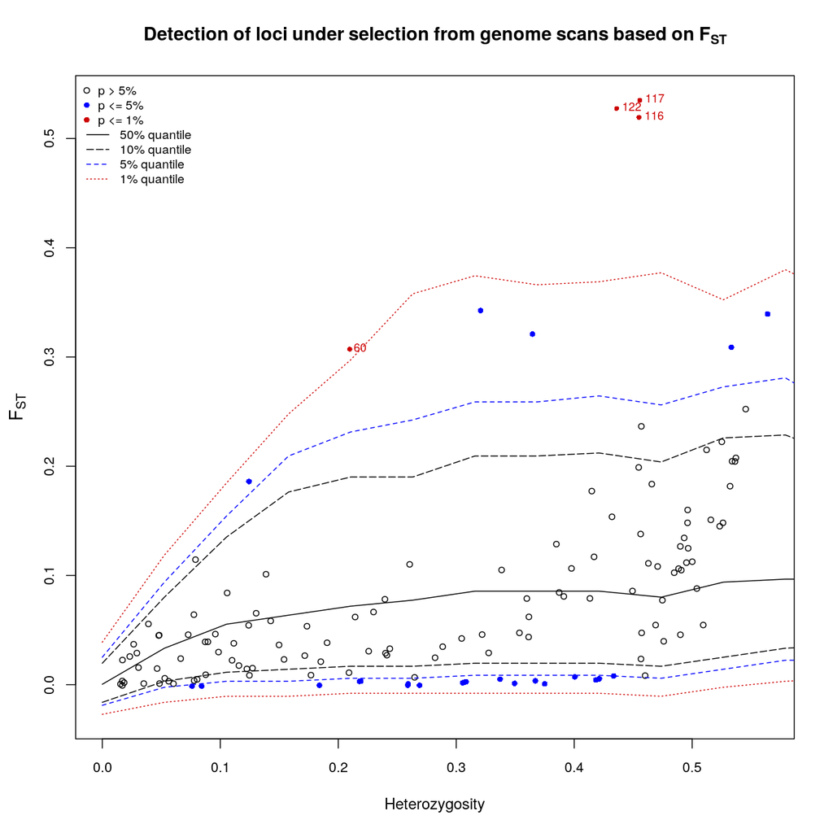

```
[1] "142_198"  "62_1_148" "98_1_305" "62_1_538"
```

### Multiple test correction

```
[1] "62_1_148" "62_1_538" "98_1_305"
```

After correction for multiple testing (FDR=0.05), 3 outlier SNP loci were detected.

## Which loci were detected as outliers by more than one method?

#### pcadapt and arlequin

```
character(0)
```

No common outlier loci detected

#### pcadapt and arlequin hierarchical model

```
character(0)
```

No common outlier loci detected

# Reproducibility

|  | setting | value |
| --- | --- | --- |
| version | version | R version 3.6.0 (2019-04-26) |
| os | os | Debian GNU/Linux 9 (stretch) |
| system | system | x86_64, linux-gnu |
| ui | ui | RStudio |
| language | language | (EN) |
| collate | collate | en_US.UTF-8 |
| ctype | ctype | en_US.UTF-8 |
| tz | tz | Etc/UTC |
| date | date | 2019-06-30 |

# Bibliography

Beaumont Mark A., and Nichols Richard A. 1996. “Evaluating Loci for Use in the Genetic Analysis of Population Structure.” *Proceedings of the Royal Society of London. Series B: Biological Sciences* 263 (1377): 1619–26. https://doi.org/10.1098/rspb.1996.0237.

Excoffier, L., T. Hofer, and M. Foll. 2009. “Detecting Loci Under Selection in a Hierarchically Structured Population.” *Heredity* 103 (4): 285–98. https://doi.org/10.1038/hdy.2009.74.

Foll, Matthieu, and Oscar Gaggiotti. 2008. “A Genome-Scan Method to Identify Selected Loci Appropriate for Both Dominant and Codominant Markers: A Bayesian Perspective.” *Genetics* 180 (2): 977–93. https://doi.org/10.1534/genetics.108.092221.

Luu, Keurcien, Eric Bazin, and Michael G. B. Blum. 2017. “Pcadapt: An R Package to Perform Genome Scans for Selection Based on Principal Component Analysis.” *Molecular Ecology Resources* 17 (1): 67–77. https://doi.org/10.1111/1755-0998.12592.

Whitlock, Michael C., and Katie E. Lotterhos. 2015. “Reliable Detection of Loci Responsible for Local Adaptation: Inference of a Null Model Through Trimming the Distribution of FST.” *The American Naturalist* 186 (S1): S24–S36. https://doi.org/10.1086/682949.